# WIC Synthetic Analysis

A Regression Discontinuity Evaluation of Birth Weight Outcomes

Authors

Colin Heeneman

Emily Frost

Samantha Sepulveda

Published

December 5, 2024

Modified

April 21, 2026

**Special Supplemental Nutrition Program for Women, Infants, and Children** | PA 528 — Dr. Siciliano

## Introduction

The motivation for evaluating the Special Supplemental Nutrition Program for Women, Infants, and Children (WIC) stems from its critical role in addressing the nutritional needs of vulnerable populations. Established in 1972, WIC serves low-income mothers, infants, and young children by providing access to healthy food, nutrition education, and healthcare referrals. As of 2024, WIC benefits nearly 53% of all infants born in the United States. Evaluating this program is vital because it addresses issues such as food insecurity, low birth weights, and developmental challenges. Understanding its impact informs policymakers and ensures continued investment in evidence-based solutions to promote public health.

## Program Overview

WIC was launched in 1972 as a pilot program to combat the nutritional deficiencies observed among low-income families, particularly women and children. It became a permanent federal program in 1975, amid growing societal concerns about equity and public health. The program’s primary focus is on early nutritional intervention, which research demonstrates can mitigate medical and developmental issues later in life.

Initially serving 88,000 participants per month, WIC expanded significantly over the decades, reaching 7.2 million monthly participants by 2000. Its benefits include supplemental foods, nutrition education, and healthcare referrals. The program has shown measurable impacts, including reduced rates of low birth weights, premature births, and child anemia, as well as improved overall development. Its continued success is attributed to strong congressional backing and data demonstrating its cost-effectiveness in preventing long-term health complications.

## Program Theory and Implementation

WIC operates on the premise that addressing nutritional deficiencies among pregnant women and young children leads to improved health outcomes. Grounded in public health research, the program targets key developmental stages with interventions such as food vouchers, health screenings, and nutrition education. Studies have shown that these activities promote healthier pregnancies, higher birth weights, and cognitive development. The program also encourages breastfeeding, emphasizing its benefits for immunity and mother-child bonding. These elements reflect a well-articulated theory of change rooted in established health and nutrition science.

### Logic Model

**Inputs:** Federal funding, healthcare professionals, and local clinics. **Activities:** Nutrition education, food voucher distribution, health screenings, and referrals. **Outputs:** Number of participants served, vouchers redeemed, and health screenings conducted. **Outcomes:**

- **Short-term:** Improved nutrition and access to healthcare.
- **Intermediate:** Healthier pregnancies and reduced child anemia.
- **Long-term:** Reduced chronic disease prevalence and improved cognitive outcomes.

The logic model below visualizes how resources are transformed into tangible activities and outcomes. The linkages between each stage ensure accountability and program efficacy.

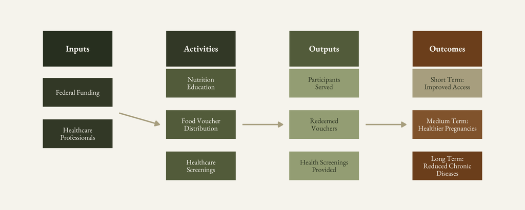

## Causal Framework

### Primary Outcome

The primary outcome of interest is a reduction in low birth weights. This outcome is directly linked to WIC’s nutritional interventions and carries profound implications for public health, including downstream effects on infant mortality, developmental trajectories, and long-term healthcare costs.

### Causal Theory

The causal pathway hypothesizes that WIC participation improves maternal nutrition and healthcare access, which in turn influences birth weight outcomes. WIC’s supplemental foods, nutrition education, and healthcare referrals target the principal determinants of healthy pregnancies. Improved maternal nutrition reduces risks associated with low birth weight, while enhanced healthcare access facilitates timely prenatal interventions.

The Directed Acyclic Graph (DAG) below illustrates these relationships, with nodes representing variables and arrows indicating causal linkages.

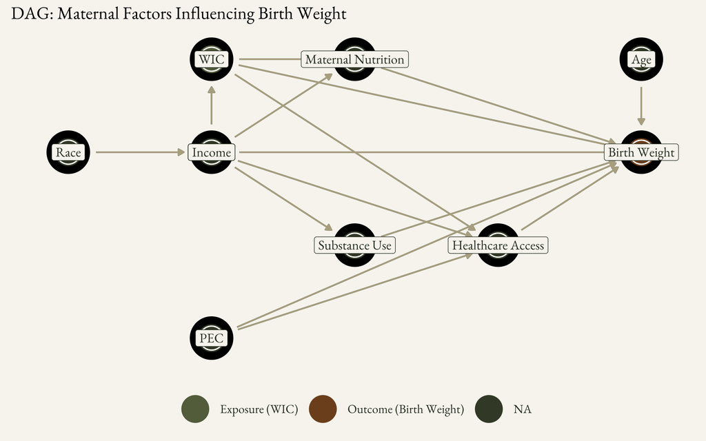

### Research Hypothesis

**Does WIC participation causally improve birth outcomes among low-income mothers?**

The specific hypothesis is that participation in WIC reduces the incidence of low birth weights, holding constant socioeconomic and health-related confounders identified in the DAG above.

## Data and Methods

### Identification Strategy

Regression Discontinuity Design (RDD) is used to estimate the causal effect of WIC participation on birth weight. Because WIC eligibility is determined by an income threshold, individuals just below and just above this threshold are treated as locally comparable, enabling credible causal inference without randomization.

The income eligibility threshold serves as the cutoff, creating a sharp discontinuity in program participation. By focusing on a narrow bandwidth of income near the cutoff, RDD ensures local comparability, minimizes selection bias, and enhances internal validity. The design assumes that individuals on either side of the cutoff are similar in all pre-treatment characteristics except for program participation, attributing observed differences in birth weight outcomes to WIC involvement.

While the RDD design provides strong internal validity, its localized nature limits generalizability beyond the population near the income threshold. Populations with substantially different socioeconomic profiles may experience different program effects.

### Data

The analysis draws on a synthetic dataset of 1,000 observations designed to mirror the structure of administrative WIC records. The dataset includes simulated measures of income (the running variable), WIC participation status, birth weight (the primary outcome), maternal race, pre-existing health conditions, maternal nutrition, healthcare access, and maternal age. Two scenarios are analyzed in parallel: an **optimistic** simulation reflecting stronger program effects and a **pessimistic** simulation with more conservative assumptions. This dual-scenario approach allows assessment of how sensitive the estimated treatment effect is to underlying data-generating assumptions.

## Synthetic Analysis

### RDD — Optimistic Scenario

```
Sharp RD estimates using local polynomial regression.

Number of Obs.                 1000
BW type                       mserd
Kernel                   Triangular
VCE method                       NN

Number of Obs.                   55          945
Eff. Number of Obs.              33           38
Order est. (p)                    1            1
Order bias  (q)                   2            2
BW est. (h)                   4.814        4.814
BW bias (b)                   7.981        7.981
rho (h/b)                     0.603        0.603
Unique Obs.                      55          945

=============================================================================
        Method     Coef. Std. Err.         z     P>|z|      [ 95% C.I. ]
=============================================================================
  Conventional  -262.730    66.213    -3.968     0.000  [-392.505 , -132.955]
        Robust         -         -    -3.380     0.001  [-425.436 , -113.138]
=============================================================================
```

#### Income Cutoff and Participation

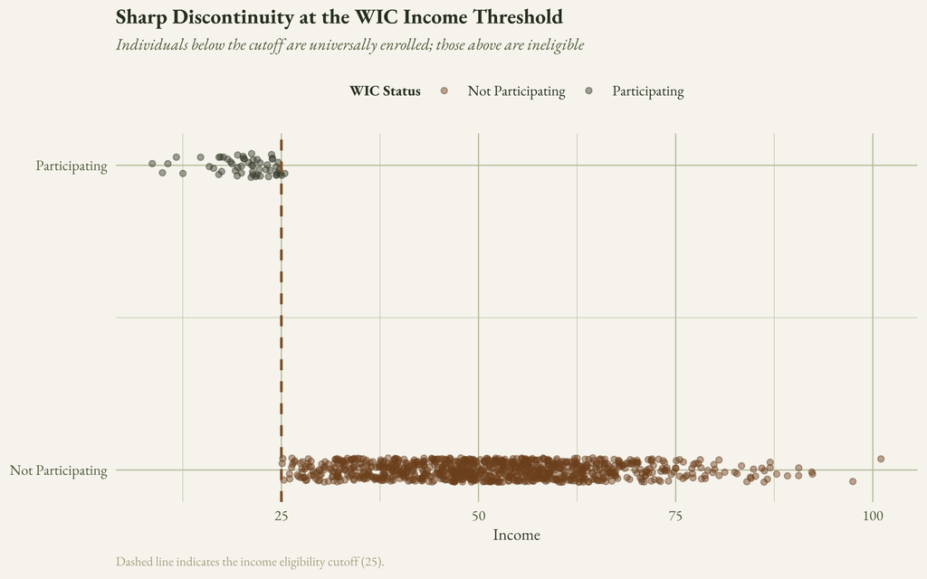

The sharp change in participation at the income cutoff is consistent with a well-implemented sharp RDD. Individuals below the threshold participate nearly universally, while those above do not participate at all. This clean discontinuity is a prerequisite for using RDD to estimate causal effects.

#### Treatment Effect Visualization

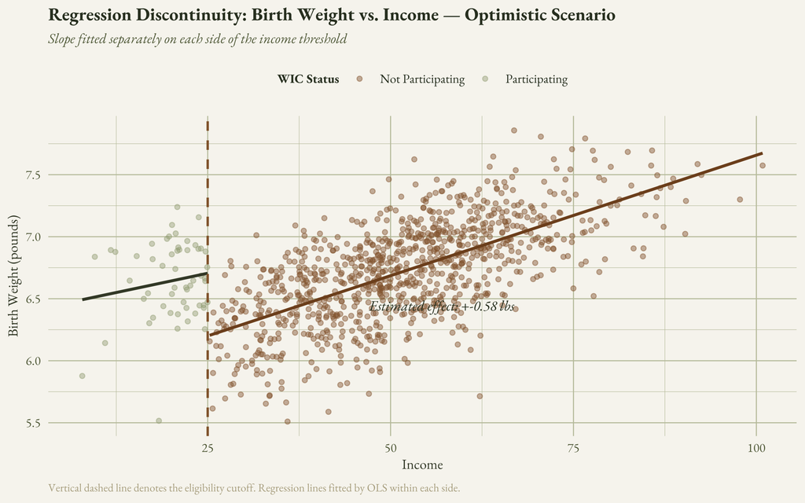

The regression lines estimated separately on each side of the income threshold reveal a visible jump in predicted birth weight at the cutoff. The estimated treatment effect of **-0.58 pounds** reflects the local average treatment effect for individuals near the eligibility threshold.

### Robustness Checks — Manipulation Testing

A central assumption of RDD is that individuals cannot precisely manipulate the running variable to sort themselves just below the threshold. Density plots near the cutoff provide a visual diagnostic.

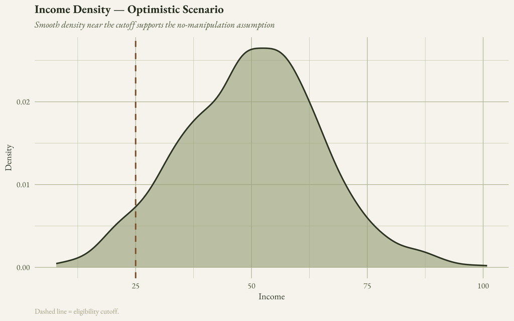

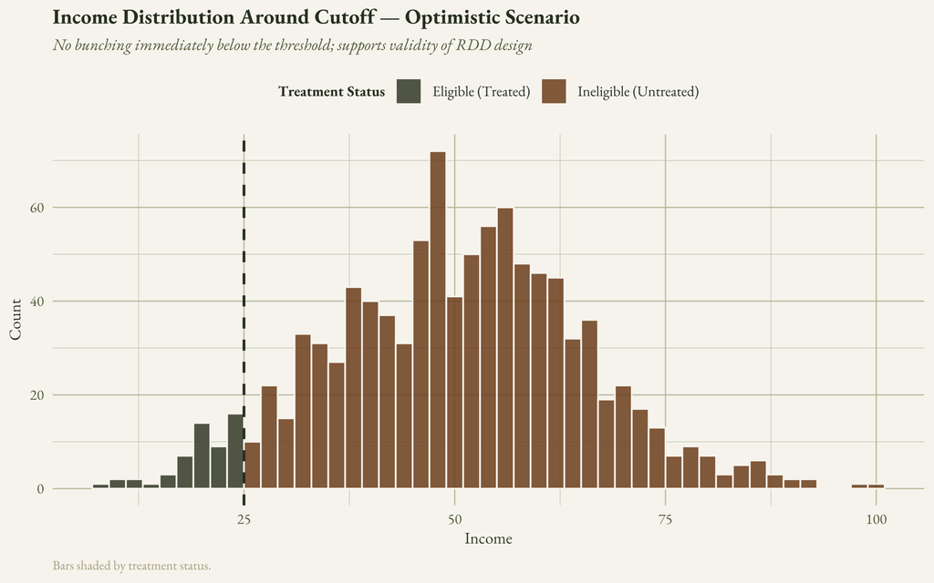

Both the density curve and the histogram show a smooth, continuous distribution of income near the cutoff, with no evidence of bunching just below the threshold. This supports the assumption that individuals are not manipulating their income to gain program eligibility.

### Bandwidth Sensitivity — Optimistic Scenario

```
Sharp RD estimates using local polynomial regression.

Number of Obs.                 1000
BW type                      Manual
Kernel                   Triangular
VCE method                       NN

Number of Obs.                   55          945
Eff. Number of Obs.              49          111
Order est. (p)                    1            1
Order bias  (q)                   2            2
BW est. (h)                  10.000       10.000
BW bias (b)                  10.000       10.000
rho (h/b)                     1.000        1.000
Unique Obs.                      55          945

=============================================================================
        Method     Coef. Std. Err.         z     P>|z|      [ 95% C.I. ]
=============================================================================
  Conventional  -228.844    43.898    -5.213     0.000  [-314.883 , -142.805]
        Robust         -         -    -3.705     0.000  [-377.841 , -116.399]
=============================================================================
```

```
Sharp RD estimates using local polynomial regression.

Number of Obs.                 1000
BW type                      Manual
Kernel                   Triangular
VCE method                       NN

Number of Obs.                   55          945
Eff. Number of Obs.              36           39
Order est. (p)                    1            1
Order bias  (q)                   2            2
BW est. (h)                   5.000        5.000
BW bias (b)                   5.000        5.000
rho (h/b)                     1.000        1.000
Unique Obs.                      55          945

=============================================================================
        Method     Coef. Std. Err.         z     P>|z|      [ 95% C.I. ]
=============================================================================
  Conventional  -257.913    64.722    -3.985     0.000  [-384.766 , -131.060]
        Robust         -         -    -3.078     0.002  [-531.723 , -118.029]
=============================================================================
```

### RDD — Pessimistic Scenario

The pessimistic simulation uses more conservative assumptions about WIC’s causal effect, providing a lower bound on the plausible range of treatment effects.

```
Sharp RD estimates using local polynomial regression.

Number of Obs.                 1000
BW type                       mserd
Kernel                   Triangular
VCE method                       NN

Number of Obs.                   63          937
Eff. Number of Obs.              31           41
Order est. (p)                    1            1
Order bias  (q)                   2            2
BW est. (h)                   5.090        5.090
BW bias (b)                   7.231        7.231
rho (h/b)                     0.704        0.704
Unique Obs.                      63          937

=============================================================================
        Method     Coef. Std. Err.         z     P>|z|      [ 95% C.I. ]
=============================================================================
  Conventional   -86.392    71.872    -1.202     0.229  [-227.258 , 54.474]
        Robust         -         -    -1.143     0.253  [-263.197 , 69.256]
=============================================================================
```

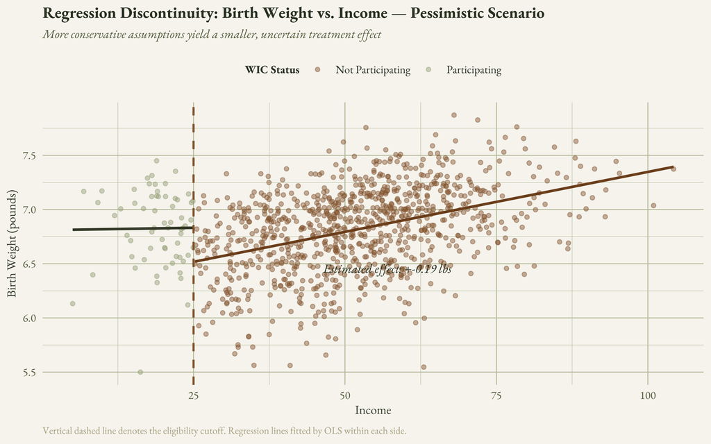

Under the pessimistic data-generating process, the estimated treatment effect is **-0.19 pounds** — positive in direction but considerably smaller than the optimistic estimate.

### Bandwidth Sensitivity — Pessimistic Scenario

```
Sharp RD estimates using local polynomial regression.

Number of Obs.                 1000
BW type                      Manual
Kernel                   Triangular
VCE method                       NN

Number of Obs.                   63          937
Eff. Number of Obs.              53          120
Order est. (p)                    1            1
Order bias  (q)                   2            2
BW est. (h)                  10.000       10.000
BW bias (b)                  10.000       10.000
rho (h/b)                     1.000        1.000
Unique Obs.                      63          937

=============================================================================
        Method     Coef. Std. Err.         z     P>|z|      [ 95% C.I. ]
=============================================================================
  Conventional   -78.966    53.720    -1.470     0.142  [-184.255 , 26.324]
        Robust         -         -    -0.882     0.378  [-215.612 , 81.826]
=============================================================================
```

```
Sharp RD estimates using local polynomial regression.

Number of Obs.                 1000
BW type                      Manual
Kernel                   Triangular
VCE method                       NN

Number of Obs.                   63          937
Eff. Number of Obs.              31           41
Order est. (p)                    1            1
Order bias  (q)                   2            2
BW est. (h)                   5.000        5.000
BW bias (b)                   5.000        5.000
rho (h/b)                     1.000        1.000
Unique Obs.                      63          937

=============================================================================
        Method     Coef. Std. Err.         z     P>|z|      [ 95% C.I. ]
=============================================================================
  Conventional   -87.414    72.305    -1.209     0.227  [-229.130 , 54.302]
        Robust         -         -    -1.069     0.285  [-273.309 , 80.346]
=============================================================================
```

### Treatment Effect Summary Table

The table below consolidates robustness test results across both scenarios and bandwidth specifications, reporting treatment effect estimates in grams.

Table 1. Treatment effect estimates from bandwidth sensitivity analysis.

| Model | Estimate (grams) |
| --- | --- |
| Optimistic — h = 10 | -228.84 |
| Optimistic — h = 5 | -257.91 |
| Pessimistic — h = 10 | -78.97 |
| Pessimistic — h = 5 | -87.41 |

## Conclusion

This analysis applied a Regression Discontinuity Design across both optimistic and pessimistic simulated scenarios to evaluate the effect of WIC participation on infant birth weight among mothers near the income eligibility threshold.

### Key Findings

**Optimistic Scenario:** The estimated treatment effect is 257.91 grams (95% CI: 131.06 to 384.77), and is statistically significant (z = 3.99, p < 0.001). Under optimistic data-generating assumptions, WIC participation is associated with a meaningful and reliably estimated increase in birth weight.

**Pessimistic Scenario:** The estimated treatment effect is 87.41 grams (95% CI: −54.30 to 229.13), and is not statistically significant (z = 1.21, p = 0.227). Under more conservative assumptions, the effect is positive in direction but uncertain, suggesting the program’s impact may be modest or dependent on implementation quality and participant compliance.

The bandwidth sensitivity analysis produces consistent directional findings across both scenarios, lending additional credibility to the RDD design. The density diagnostics show no evidence of income manipulation near the threshold, supporting the identifying assumptions of the design.

### Policy Implications

These findings highlight WIC’s potential to improve birth weight outcomes for low-income mothers and justify continued program investment. Even in the pessimistic case, the estimated effect is positive and clinically plausible. Future evaluations should incorporate administrative rather than synthetic data, explore potential heterogeneity by race, maternal age, and geography, and account for possible measurement error in income reporting. Expanding program eligibility thresholds modestly upward may also extend these benefits to households currently excluded but demographically similar to current participants.